# Weekend6 Homework - Kirsty

# 1.1 Hypothesis testing - practical

#### Q1: Explore the dataset and familiarise yourself with it.

```r
library(tidyverse)
library(infer)
```

```r
data(msleep)
```

```r
head(msleep)
```

| name | genus | vore | order | conservation | sleep_total | sleep_rem | sleep_cycle | awake | brainwt | bodywt |
| --- | --- | --- | --- | --- | --- | --- | --- | --- | --- | --- |
| Cheetah | Acinonyx | carni | Carnivora | lc | 12.1 | NA | NA | 11.9 | NA | 50.000 |
| Owl monkey | Aotus | omni | Primates | NA | 17.0 | 1.8 | NA | 7.0 | 0.01550 | 0.480 |
| Mountain beaver | Aplodontia | herbi | Rodentia | nt | 14.4 | 2.4 | NA | 9.6 | NA | 1.350 |
| Greater short-tailed shrew | Blarina | omni | Soricomorpha | lc | 14.9 | 2.3 | 0.1333333 | 9.1 | 0.00029 | 0.019 |
| Cow | Bos | herbi | Artiodactyla | domesticated | 4.0 | 0.7 | 0.6666667 | 20.0 | 0.42300 | 600.000 |
| Three-toed sloth | Bradypus | herbi | Pilosa | NA | 14.4 | 2.2 | 0.7666667 | 9.6 | NA | 3.850 |

#### Q2: Jabberwockies sleep for around 7 hours a night, on average. Perform an appropriate statistical test to determine whether the mean sleep_total in the sampled population of animal types differs from the typical value for Jabberwockies.

##### Test type: one sample mean

##### 1. Define Null & Alternative Hypotheses:

**H0: The mean sleep_total in the sampled population does not differ from 7 hours**

$H_0:$ $\mu {\textrm{Sleep_Total}} = 7$

**Ha: The mean sleep_total in the sampled population does differ from the sleep_total of Jabberwockies**

$H_a:$ $\mu {\textrm{Sleep_Total}} \neq 7$

Significance Level: 0.05

##### 2. Calculate Test Statistic:

```r
observed_stat_jabberwockies <- msleep %>%
  summarise(mean_sleep_total = mean(sleep_total))

observed_stat_jabberwockies
```

| mean_sleep_total |
| --- |
| 10.43373 |

The mean of sleep_total is 10.43 hours, which is higher than our expected value of 7 hours.

##### 3. Generate the Null Distribution:

```r
null_distribution_jabberwockies <- msleep %>%
  specify(response = sleep_total) %>%
  hypothesise(null = "point", mu = 7) %>%
  generate(reps = 2000, type = "bootstrap") %>%
  calculate(stat = "mean")

# generate a null distribution centred around a mean of 7, for each replicate calculate the average
```

##### 4. Visualise the Null Distribution and Observed Statistic:

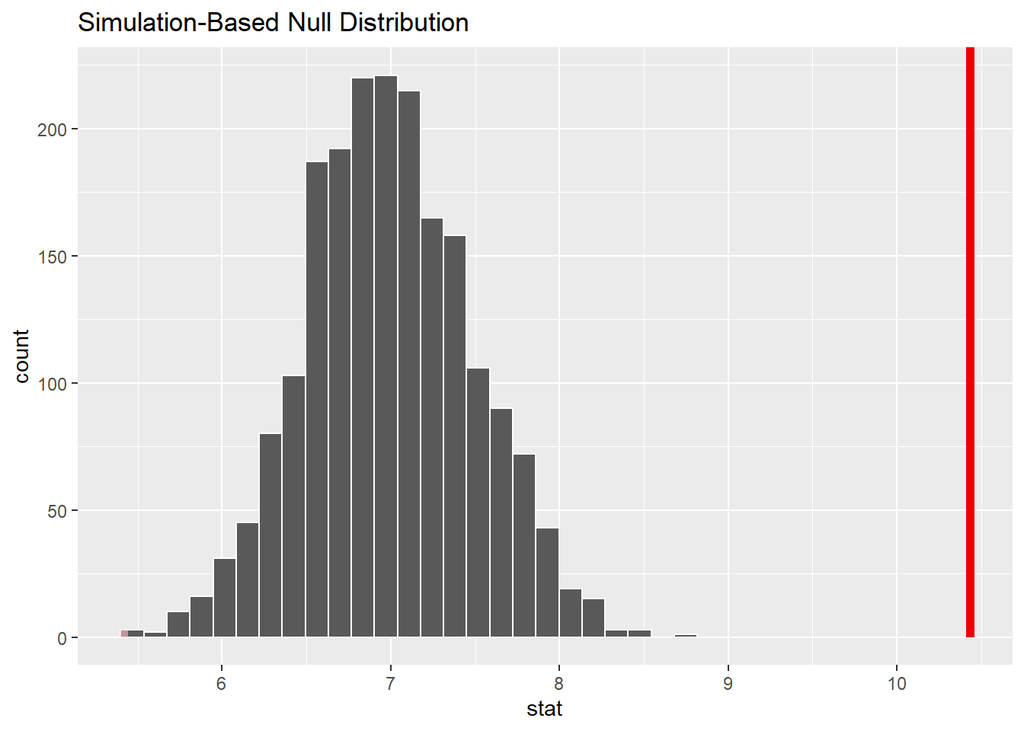

```r
null_distribution_jabberwockies %>%
visualise(bins = 25) +
shade_p_value(obs_stat = observed_stat_jabberwockies$mean_sleep_total,
                direction = "both") # direction = both as we want to know how much it differs in either direction
```

From this visualisation, it is evident that the actual average differs significantly from the hypothesised average

##### 5. Calculate the P-Value:

```r
null_distribution_jabberwockies %>%
  get_p_value(
    obs_stat = observed_stat_jabberwockies$mean_sleep_total,
    direction = "both"
  )
```

| p_value |
| --- |
| 0 |

Significance level α = 0.05

The P value of 0 is less than the significance level of 0.05, therefore we may reject H0 in favour of Ha. Thus, the mean sleep_total in the sampled population does differ significantly from the average sleep total of 7 hours for Jabberwockies.

#### Q3: Perform an appropriate statistical test to determine whether omnivores sleep for significantly longer than herbivores, on average.

##### Test type: Independent, two sample test

##### 1. Define Null & Alternative Hypotheses & Explore Data

**H0: On average, omnivores *do not* sleep significantly longer than herbivores**

$H_0:$ $\mu {\textrm{Sleep_Total of Omnivores}} - \mu {\textrm{Sleep_Total of Herbivores}} = 0$

**Ha: On average, omnivores *do* sleep significantly longer than herbivores**

$H_a:$ $\mu {\textrm{Sleep_Total of Omnivores}} - \mu {\textrm{Sleep_Total of Herbivores}} > 0$

Significance Level: 0.05

```r
# filter data set to only include omnivore and herbivore data

msleep_omni_herbi <- msleep %>%
  filter(vore == c("omni", "herbi"))
```

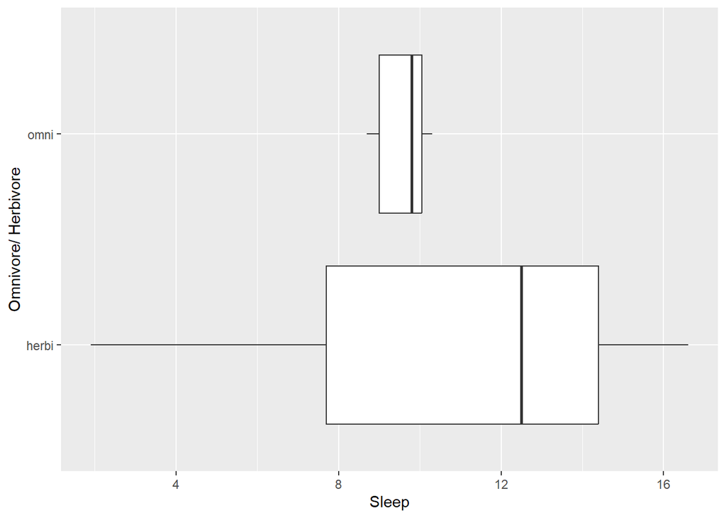

```r
# What does the distribution of sleep_total look like for each "vore"?

msleep_omni_herbi %>%
  ggplot(aes(x = sleep_total, y = vore)) +
  geom_boxplot() +
  ylab("Omnivore/ Herbivore") +
  xlab("Sleep")
```

From the box plot, it appears that on average herbivores sleep longer than omnivores, and have a much broader range of hours slept.

##### 2. Calculate Test Statistic:

```r
observed_stat_omni_herbi <- msleep_omni_herbi %>%
  specify(response = sleep_total, explanatory = vore) %>%
  calculate(stat = "diff in means", order = c("omni", "herbi"))

observed_stat_omni_herbi
```

| stat |
| --- |
| -0.8957983 |

##### 3. Generate the Null Distribution:

```r
null_distribution_omni_herbi <- msleep_omni_herbi %>%
  specify(response = sleep_total, explanatory = vore) %>%
  hypothesise(null = "independence") %>%
  generate(reps = 2000, type = "permute") %>%
  calculate(stat = "diff in means", order =c("omni", "herbi"))

head(null_distribution_omni_herbi)
```

| replicate | stat |
| --- | --- |
| 1 | -2.408403 |
| 2 | 1.020168 |
| 3 | -1.924370 |
| 4 | -1.500840 |
| 5 | 1.968067 |
| 6 | 2.068908 |

##### 4. Visualise the Null Distribution and Observed Statistic:

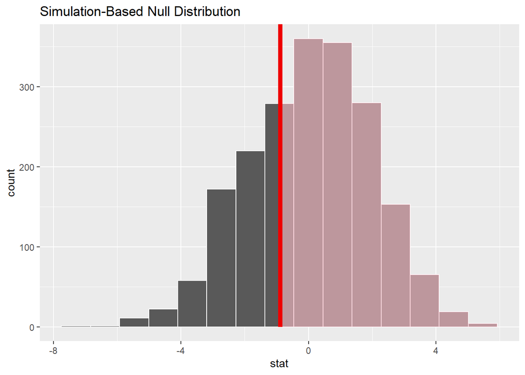

```r
null_distribution_omni_herbi%>%
visualise() +
  shade_p_value(obs_stat = observed_stat_omni_herbi$stat,
                direction = "greater")
```

##### 5. Calculate the P-Value:

```r
null_distribution_omni_herbi %>%
  get_p_value(obs_stat = observed_stat_omni_herbi$stat,
                direction = "greater")
```

| p_value |
| --- |
| 0.695 |

Significance level α = 0.05

#### Q4: Perform an appropriate statistical test to determine whether the proportion of domesticated animal types in the population of animal types is greater than 5%

##### Test type: One sample proportion test

##### 1. Define Null & Alternative Hypotheses:

**H0 = The proportion of domesticated animal types in the overall population of animal types is less than 5%.**

$H_0:$ $\pi{\textrm{Domesticated Animal Types}} < 5\%$

**Ha = The proportion of domesticated animal types in the overall population of animal types is greater than 5%.**

$H_a:$ $\pi{\textrm{Domesticated Animal Types}} > 5\%$

Significance Level: 0.05

##### 2. Calculate Test Statistic:

```r
msleep_tidy <- msleep %>%
  drop_na(conservation)

# prop with conservation = domesticated:

observed_stat_domesticated <- msleep_tidy %>%
  group_by(conservation) %>%
  summarise(prop = n()/nrow(msleep_tidy)) %>%
  filter(conservation == "domesticated")

observed_stat_domesticated
```

| conservation | prop |
| --- | --- |
| domesticated | 0.1851852 |

##### 3. Generate the Null Distribution:

```r
# generate a column specifying if the conservation class is domesticated or not

msleep_tidy <- msleep_tidy %>%
  mutate(domesticated = if_else(conservation == "domesticated", "domesticated", "other"), .after = conservation)

msleep_tidy
```

| name | genus | vore | order | conservation | domesticated | sleep_total | sleep_rem | sleep_cycle | awake | brainwt | bodywt |
| --- | --- | --- | --- | --- | --- | --- | --- | --- | --- | --- | --- |
| Cheetah | Acinonyx | carni | Carnivora | lc | other | 12.1 | NA | NA | 11.90 | NA | 50.000 |
| Mountain beaver | Aplodontia | herbi | Rodentia | nt | other | 14.4 | 2.4 | NA | 9.60 | NA | 1.350 |
| Greater short-tailed shrew | Blarina | omni | Soricomorpha | lc | other | 14.9 | 2.3 | 0.1333333 | 9.10 | 0.00029 | 0.019 |
| Cow | Bos | herbi | Artiodactyla | domesticated | domesticated | 4.0 | 0.7 | 0.6666667 | 20.00 | 0.42300 | 600.000 |
| Northern fur seal | Callorhinus | carni | Carnivora | vu | other | 8.7 | 1.4 | 0.3833333 | 15.30 | NA | 20.490 |
| Dog | Canis | carni | Carnivora | domesticated | domesticated | 10.1 | 2.9 | 0.3333333 | 13.90 | 0.07000 | 14.000 |
| Roe deer | Capreolus | herbi | Artiodactyla | lc | other | 3.0 | NA | NA | 21.00 | 0.09820 | 14.800 |
| Goat | Capri | herbi | Artiodactyla | lc | other | 5.3 | 0.6 | NA | 18.70 | 0.11500 | 33.500 |
| Guinea pig | Cavis | herbi | Rodentia | domesticated | domesticated | 9.4 | 0.8 | 0.2166667 | 14.60 | 0.00550 | 0.728 |
| Grivet | Cercopithecus | omni | Primates | lc | other | 10.0 | 0.7 | NA | 14.00 | NA | 4.750 |

[output cut: 44 more lines]

```r
null_distribution_domesticated <- msleep_tidy %>%
  specify(response = domesticated, success = "domesticated") %>%
  hypothesise(null = "point", p = 0.05) %>%
  generate(reps = 2000, type = "draw") %>%
  calculate(stat = "prop")

head(null_distribution_domesticated)
```

| replicate | stat |
| --- | --- |
| 1 | 0.11111111 |
| 2 | 0.01851852 |
| 3 | 0.05555556 |
| 4 | 0.05555556 |
| 5 | 0.00000000 |
| 6 | 0.03703704 |

##### 4. Visualise the Null Distribution and Observed Statistic:

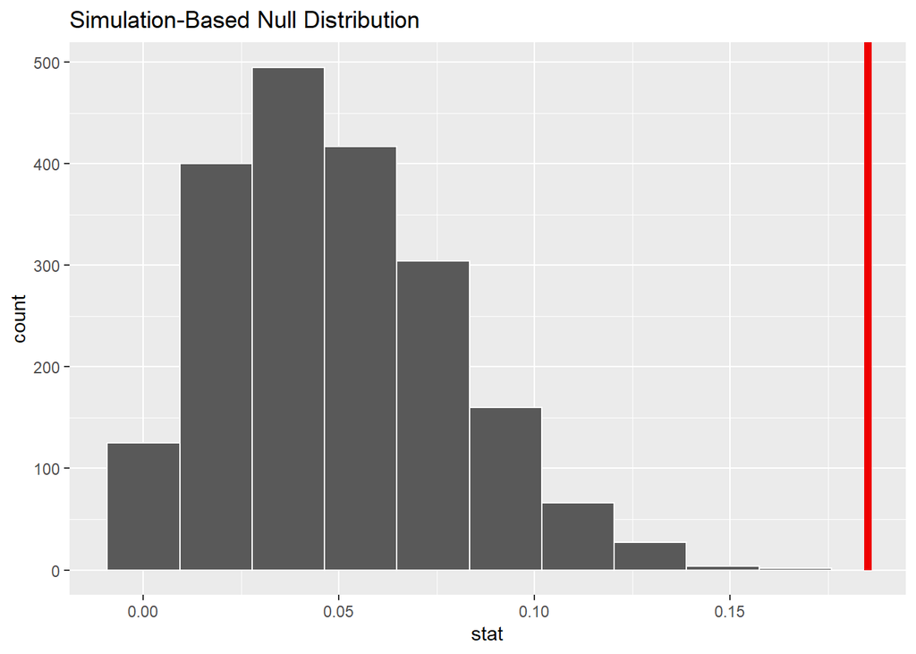

```r
null_distribution_domesticated %>%
  visualise(bins = 10) +
  shade_p_value(obs_stat = observed_stat_domesticated$prop,
                direction = "greater")
```

As the observed statistic lies to the right of the null distribution, it is likely that the proportion is >5%.

##### 5. Calculate the P-Value:

```r
null_distribution_domesticated %>%
  get_p_value(obs_stat = observed_stat_domesticated$prop,
              direction = "greater")
```

| p_value |
| --- |
| 0 |

Significance level α = 0.05

The P value of 0 is significantly lower than the significance level of 0.05, therefore we reject H0 in favour of Ha. Thus, the proportion of domesticated animal types in the overall population of animal types is greater than 5%.

# 1.2 Hypothesis testing - Defining the Hypothesis

#### Q1: Coffee Shop

##### **Test:**

One sample test of proportion

##### **H0 & Ha:**

H0: The proportion of the population of the town that have heard of the coffee shop is 40%.  
$H_0:$ $\pi{\textrm{Population with Awareness of Coffee Shop}} = 40\%$

Ha: The proportion of the population of the town that have heard of the coffee shop is more than 40%.

$H_a:$ $\pi{\textrm{Population with Awareness of Coffee Shop}} > 40\%$

##### **Null Distribution Method:**

Draw - creates a world where the proportion is equal to 40

#### Q2: Website Design

##### **Test:**

Independent, two sample test of the difference in the means of each group

##### **H0 & Ha:**

H0: On average, the CTR of Group B was the same as or less than that of Group A

$H_0:$ $\mu {\textrm{Group B}} ≤ \mu {\textrm{Group A}}$

Ha: On average, the CTR of Group B was higher than that of Group A

$H_a:$ $\mu {\textrm{Group B}} > \mu {\textrm{Group A}}$

##### **Null Distribution Method:**

Permute - as the H0 is that the difference in means is equal to 0, permute allows a distribution to be made based on the shuffling of the labels, rather than distributing the mean.

#### Q3: Manufacturing Company

##### **Test:**

One sample test of one mean

##### **H0 & Ha:**

The mean width of the part is 145mm

$H_0:$ $\mu {\textrm{Part Width}} = {\textrm{145mm}}$

Ha: The mean width of the part is not 145mm

$H_a:$ $\mu {\textrm{Part Width}} \neq {\textrm{145mm}}$

##### **Null Distribution Method:**

Bootstrap to create a distribution that is centered around the expect mean of 145mm.

# 1.3 Hypothesis Testing - Interpreting the results

#### **Q1: Coffee Shop**

α = 0.05  
P = 0.07

Since P > α, we would fail to reject the null hypothesis, and therefore state that the proportion of the population of the town that have heard of the coffee shop *is* around 40%, as assumed by the boss.

#### **Q2: Website Design**

α = 0.01  
P = 0.006

Since P < α, we would reject the null hypothesis, and therefore state that on average, the “click through rate” (CTR) of Group B was higher than that of Group A, meaning that moving the banner to the top of the page *did* have a significantly positive impact on CTR.

#### **Q3: Manufacturing Company**

α = 0.05  
P = 0.55

Since P > α, we would fail to reject the null hypothesis, and therefore state that the mean width of the particular car part did not drift from 145mm.

# Extension

```r
transactions <- read_csv("data/online_retail_subset.csv") %>%  janitor::clean_names()
```

```r
head(transactions, 20)
```

| invoice_no | stock_code | description | invoice_date | unit_price | customer_id | country |
| --- | --- | --- | --- | --- | --- | --- |
| 536365 | 85123A | WHITE HANGING HEART T-LIGHT HOLDER | 12/1/10 8:26 | 2.55 | 17850 | United Kingdom |
| 536365 | 71053 | WHITE METAL LANTERN | 12/1/10 8:26 | 3.39 | 17850 | United Kingdom |
| 536365 | 84406B | CREAM CUPID HEARTS COAT HANGER | 12/1/10 8:26 | 2.75 | 17850 | United Kingdom |
| 536365 | 84029G | KNITTED UNION FLAG HOT WATER BOTTLE | 12/1/10 8:26 | 3.39 | 17850 | United Kingdom |
| 536365 | 84029E | RED WOOLLY HOTTIE WHITE HEART. | 12/1/10 8:26 | 3.39 | 17850 | United Kingdom |
| 536365 | 22752 | SET 7 BABUSHKA NESTING BOXES | 12/1/10 8:26 | 7.65 | 17850 | United Kingdom |
| 536365 | 21730 | GLASS STAR FROSTED T-LIGHT HOLDER | 12/1/10 8:26 | 4.25 | 17850 | United Kingdom |
| 536366 | 22633 | HAND WARMER UNION JACK | 12/1/10 8:28 | 1.85 | 17850 | United Kingdom |
| 536366 | 22632 | HAND WARMER RED POLKA DOT | 12/1/10 8:28 | 1.85 | 17850 | United Kingdom |
| 536367 | 84879 | ASSORTED COLOUR BIRD ORNAMENT | 12/1/10 8:34 | 1.69 | 13047 | United Kingdom |

[output cut: 10 more lines]

```r
# total number of transactions = number of unique invoice numbers

transaction_count <- transactions %>%
  distinct(invoice_no) %>%
  nrow()

transaction_count
```

```
## [1] 1406
```

#### Q1: Calculate the support for item A (this will be the support for a single item)

item A =‘HEART OF WICKER SMALL’ (StockCode 22469) item B =‘LARGE CAKE TOWEL PINK SPOTS’ (StockCode 21110)

sup(A) = P(A) = no. transactions involving A / total no. of transactions

```r
sup_A <- transactions %>%
  filter(stock_code == "22469") %>%
  distinct(invoice_no) %>% # some orders involve >1 count of A, we just want the count of each unique transaction id involving A
  nrow()/transaction_count # divide this by number of unique transaction IDs

sup_A
```

```
## [1] 0.07681366
```

#### Q2: Calculate the support and confidence for rule (A→B)

sup(A→B)= P(A + B being purchased together) = no. of transactions of A + B / total transactions

p(A&B):

```r
trans_A_B <- transactions %>%
  group_by(invoice_no) %>%
  filter(stock_code %in% c("22469", "21110")) %>% # find rows that contain either code
  filter(n_distinct(stock_code) > 1) # filter for groups (invoices) that have >1 code in the above filter, and therefore contain both items

trans_A_B
```

| invoice_no | stock_code | description | invoice_date | unit_price | customer_id | country |
| --- | --- | --- | --- | --- | --- | --- |
| 536592 | 21110 | LARGE CAKE TOWEL PINK SPOTS | 12/1/10 17:06 | 13.57 | NA | United Kingdom |
| 536592 | 22469 | HEART OF WICKER SMALL | 12/1/10 17:06 | 3.36 | NA | United Kingdom |
| 537144 | 22469 | HEART OF WICKER SMALL | 12/5/10 13:00 | 1.65 | 15880 | United Kingdom |
| 537144 | 21110 | LARGE CAKE TOWEL PINK SPOTS | 12/5/10 13:00 | 6.75 | 15880 | United Kingdom |
| 538071 | 21110 | LARGE CAKE TOWEL PINK SPOTS | 12/9/10 14:09 | 13.57 | NA | United Kingdom |
| 538071 | 22469 | HEART OF WICKER SMALL | 12/9/10 14:09 | 3.36 | NA | United Kingdom |
| 538349 | 21110 | LARGE CAKE TOWEL PINK SPOTS | 12/10/10 14:59 | 13.57 | NA | United Kingdom |
| 538349 | 22469 | HEART OF WICKER SMALL | 12/10/10 14:59 | 3.36 | NA | United Kingdom |
| 538524 | 21110 | LARGE CAKE TOWEL PINK SPOTS | 12/13/10 9:35 | 13.57 | NA | United Kingdom |
| 538524 | 22469 | HEART OF WICKER SMALL | 12/13/10 9:35 | 3.36 | NA | United Kingdom |

```r
sup_A_B <- nrow(trans_A_B)/transaction_count
# number of transactions involving A + B/ number of unique transactions
sup_A_B
```

```
## [1] 0.007112376
```

```r
conf_A_B <- sup_A_B / sup_A
# P(A + B purchased together)/ P(A being purchased)

conf_A_B
```

```
## [1] 0.09259259
```

#### Q3: Calculate the lift for (A→B)

sup(B) = number of transactions involving B/ total number of transactions

```r
sup_B <- transactions %>%
  filter(stock_code == "21110") %>%
  distinct(invoice_no) %>% # some orders involve >1 count of A, we just want the count of each unique transaction id involving A
  nrow()/transaction_count # divide this by number of unique transaction IDs

sup_B
```

```
## [1] 0.009957326
```

lift(A→B)=sup(A→B)/sup(A)×sup(B)

```r
lift_A_B <- sup_A_B / (sup_A * sup_B)

lift_A_B
```

```
## [1] 9.298942
```

As lift(A→B)>1, items A and B are more likely to be bought together.